# Homework4

Federico Veronesi

2023-10-24

## Exercise 1

### Point a

```r
library(smacof)
library(prabclus)
```

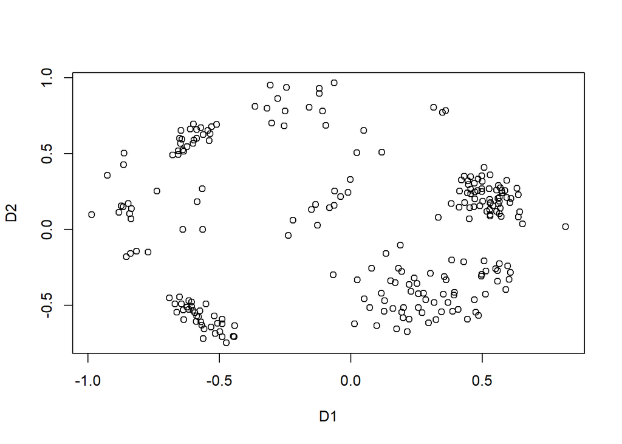

```r
data(tetragonula)
ta <- alleleconvert(strmatrix=tetragonula)
tai <- alleleinit(allelematrix=ta)
dis <- tai$distmat
mdscaling <- mds(as.matrix(dis))
plot(mdscaling$conf)
```

```r
mdscaling$stress
```

```
## [1] 0.2619208
```

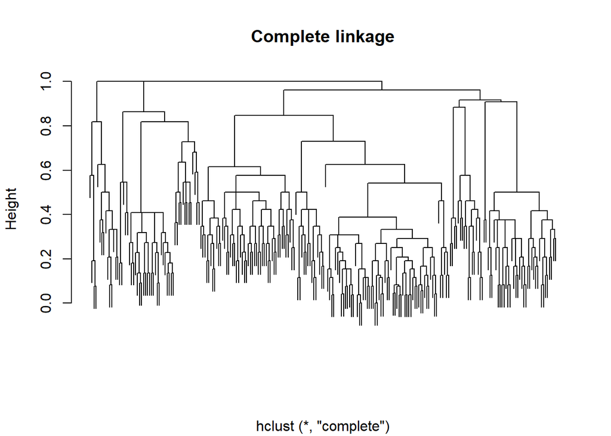

```r
# hierarchical methods (compl linkage, single linkage, avg linkage)
complink <- hclust(as.dist(dis), method = "complete")
plot(complink, labels = F, main = "Complete linkage", xlab = "")
```

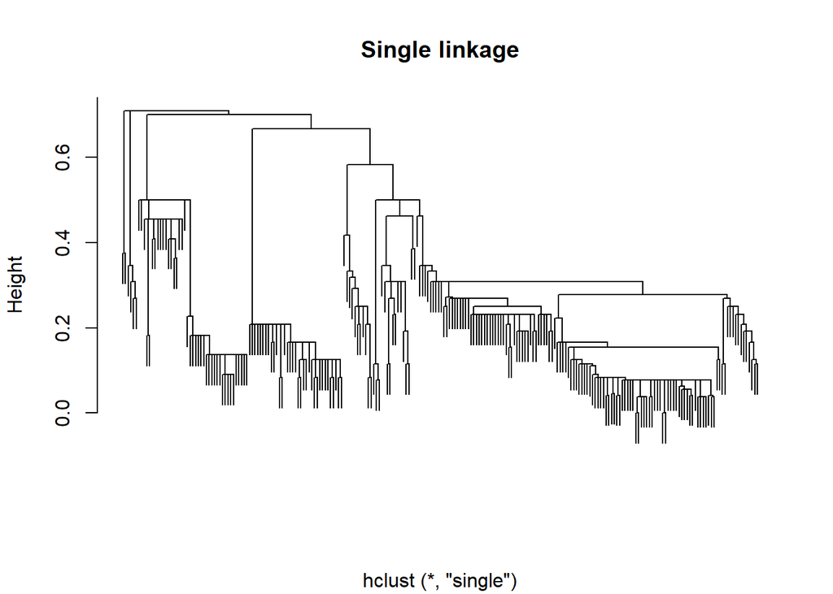

```r
# hierarchical methods (compl linkage, single linkage, avg linkage)
singlink <- hclust(as.dist(dis), method = "single")
plot(singlink, labels = F, main = "Single linkage", xlab = "")
```

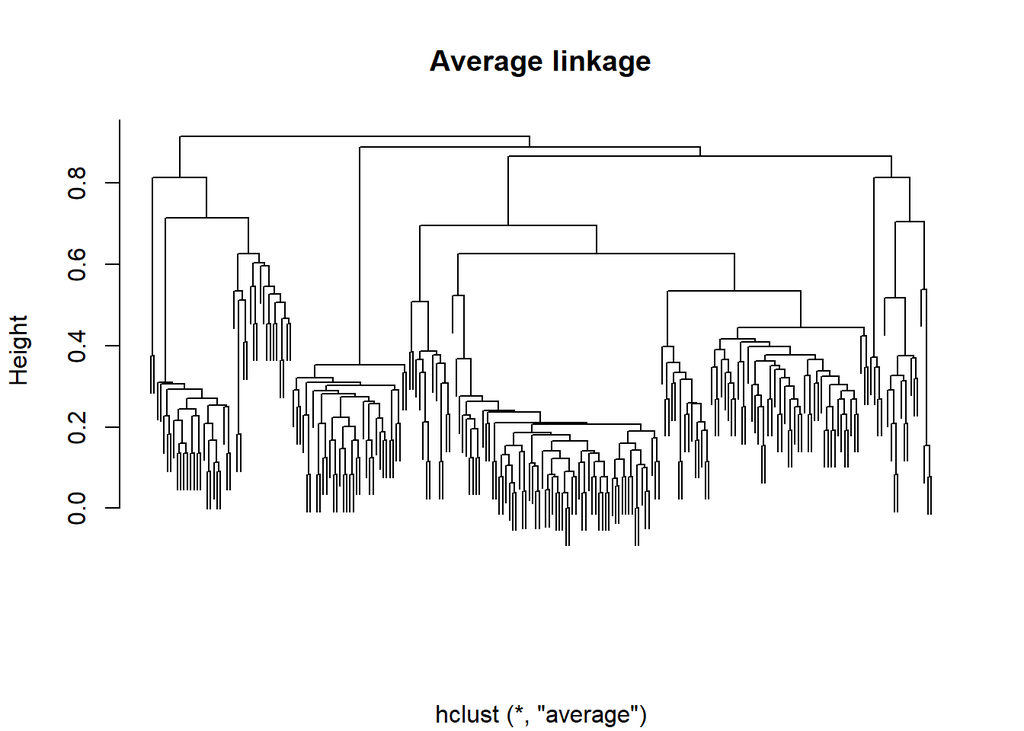

```r
# hierarchical methods (compl linkage, single linkage, avg linkage)
avglink <- hclust(as.dist(dis), method = "average")
plot(avglink, labels = F, main = "Average linkage", xlab = "")
```

Here I decided to use the average linkage method since it’s a compromise between separation(single linkage) and homogeneity between clusters (complete linkage). Since I have small knowledge about genetic data and how to cluster it, the chosen method is the one which is less “extreme”. The choice of k=6 allows to have clusters with a reasonable number of observations. Plus, I did not opt for a smaller k since the following aggregations happened at too big values of height.

```r
library(fpc)
```

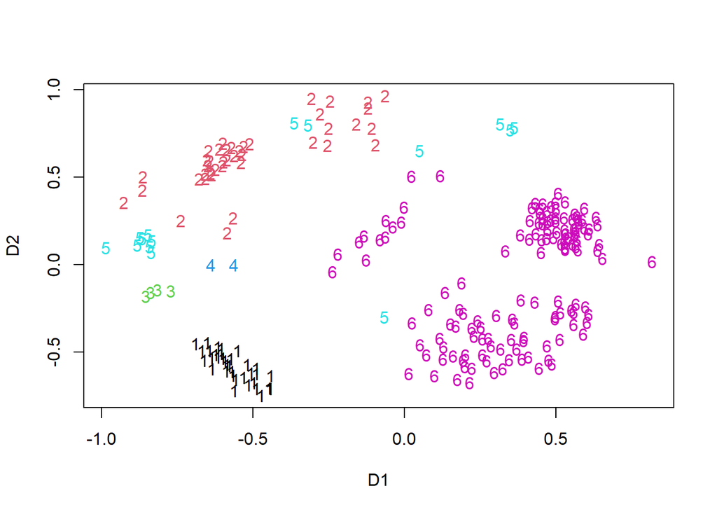

```r
avglink6 <- cutree(avglink, k=6)
plot(mdscaling$conf,col=avglink6,pch=clusym[avglink6])
```

There are some units that seem to be placed in the wrong cluster, that’s probably because multidimensional scaling loses a quite high quantity of information (about 26%).

### Point b

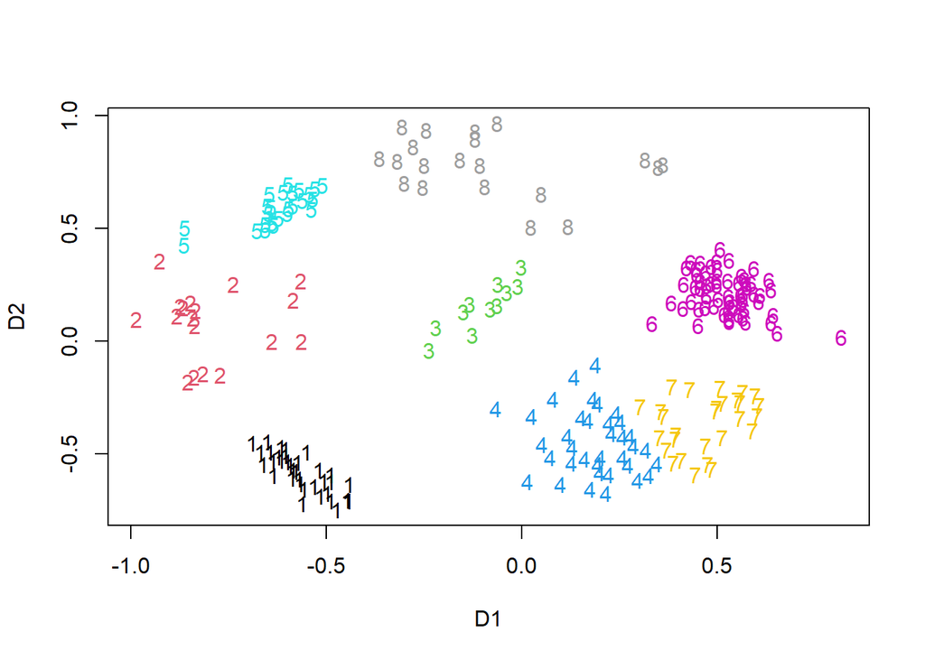

```r
#kmeans on mds values
library(cluster)

gapnc <- function(data,FUNcluster=kmeans, K.max=10, B = 100, d.power = 2, spaceH0 ="scaledPCA", method ="globalSEmax", SE.factor = 2,...)
{
gap1 <- clusGap(data,kmeans,K.max, B, d.power,spaceH0,...)
nc <- maxSE(gap1$Tab[,3],gap1$Tab[,4],method, SE.factor)
kmopt <- kmeans(data,nc,...)
out <- list()
out$gapout <- gap1
out$nc <- nc
out$kmopt <- kmopt
out
}

gap_output <- gapnc(mdscaling$conf, K.max = 10, nstart=100, SE.factor = 2)
mdsdata <- as.data.frame(mdscaling$conf)
mdsdata$cl <- gap_output$kmopt$cluster
plot(mdsdata[,1:2],col=mdsdata$cl,pch=clusym[mdsdata$cl])
```

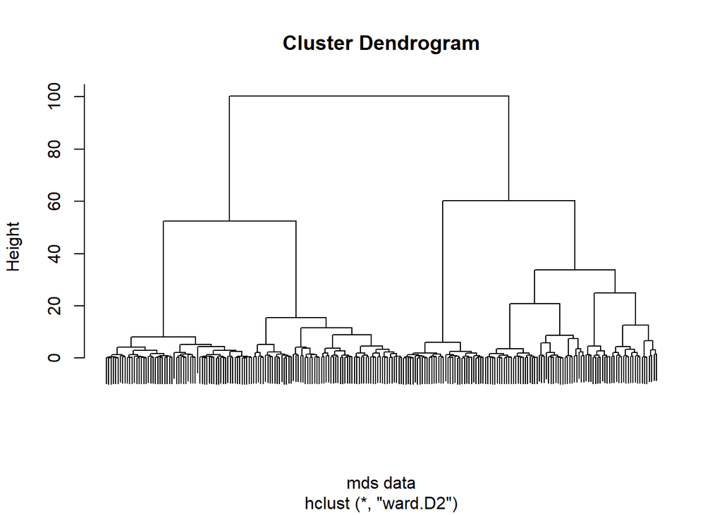

```r
#ward method on mds values
eucldist <- dist(mdsdata[,1:2], method = "euclidean")
ward <-  hclust(dist(eucldist),method="ward.D2")
plot(ward, labels=FALSE, xlab = "mds data")
```

```r
# 4 seems to be a reasonable n°of clusters
```

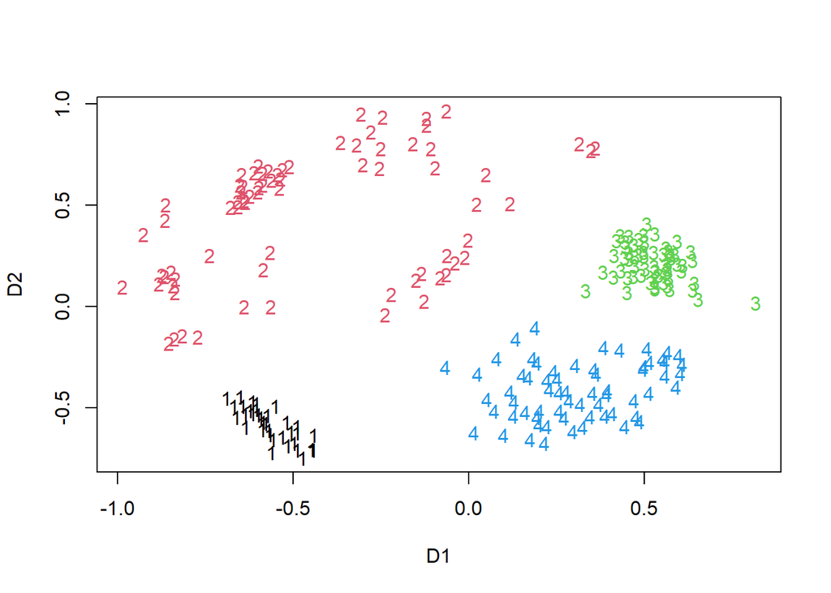

```r
ward4 <- cutree(ward, k=4)
mdsdata$cl <- ward4
plot(mdsdata[,1:2],col=mdsdata$cl,pch=clusym[mdsdata$cl])
```

```r
#mixture models
library(mclust)
mixtmdsdata <- Mclust(mdsdata[,1:2],G=1:8)
summary(mixtmdsdata)    #VVE with 7 components is chosen
```

```
## ----------------------------------------------------
## Gaussian finite mixture model fitted by EM algorithm
## ----------------------------------------------------
##
## Mclust VVE (ellipsoidal, equal orientation) model with 7 components:
##
##  log-likelihood   n df       BIC       ICL
##        11.20011 236 35 -168.8339 -171.0657
##
## Clustering table:
##  1  2  3  4  5  6  7
## 35 23 16 20 15 63 64
```

```r
summary(mixtmdsdata$BIC)
```

```
## Best BIC values:
##              VVE,7       VVV,7       VVE,8
## BIC      -168.8339 -171.559535 -176.686823
## BIC diff    0.0000   -2.725638   -7.852926
```

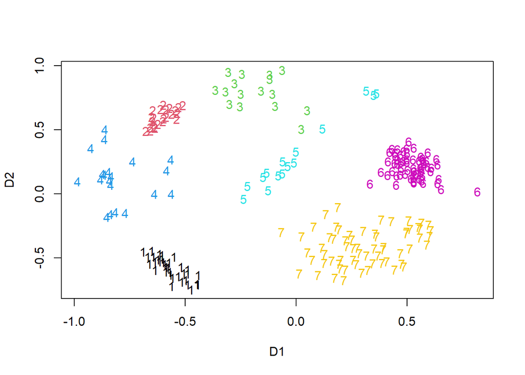

```r
mdsdata$cl <- mixtmdsdata$classification
plot(mdsdata[,1:2],col=mdsdata$cl,pch=clusym[mdsdata$cl])
```

The main advantage of this approach is that our data are transformed in euclidean data: working on euclidean distances is simpler for many applications and for interpretation. The main drawback is the loss of information: this is quantified by the quantity “stress” computed above, and we could say that, in applying multidim.scaling to 2 dimensions, we lose a big amount of information.  
As a consequence, I don’t think that this approaches are ultimately better, because we perform a clustering method on data that are not the original ones, and we don’t see the whole “picture” in this way, in particular on only 2 dimensions. I would prefere the use of MDS in 2 dimensions only for graphical and visualization purposes.  
In this task, Multidimensional Scaling in only 2 dimensions loses a remarkable quantity of information (26%). For this reason, I would say that a multidim.scaling in 3 or more dimensional would be better, since we would lose less information before applying a clustering method. However, using 3 dimensions, it would be impossible to produce a scatterplot and visualize correctly the clusters.

## Exercise 2

```r
## Data preparation
setwd("C:/Users/Veronesi/Desktop/uniBo/Magistrale/Modern Statistics and Big Data Analytics")
wdbc <- read.table("wdbc.data", sep = ",")
# so wbbcc is the data set to be clustered:
wdbcc <- wdbc[,3:12]
wdbc[,2] <- as.factor(wdbc[,2])
# There is also a diagnosis whether cancer is benign or malign as variable 2
# in the data set:
wdbcdiag <- as.integer(wdbc[,2])
```

### Gaussian mixture model

```r
#mixture models
library(mclust)
mixtwdbc <- Mclust(wdbc,G=2:10)
summary(mixtwdbc)
```

```
## ----------------------------------------------------
## Gaussian finite mixture model fitted by EM algorithm
## ----------------------------------------------------
##
## Mclust VEV (ellipsoidal, equal shape) model with 3 components:
##
##  log-likelihood   n   df      BIC      ICL
##        17080.95 569 1620 23884.82 23884.43
##
## Clustering table:
##   1   2   3
##  57 182 330
```

```r
summary(mixtwdbc$BIC)    ##vev with 3 components is chosen
```

```
## Best BIC values:
##             VEV,3     VEV,4     VEV,5
## BIC      23884.82 21792.038 20310.252
## BIC diff     0.00 -2092.777 -3574.563
```

### Ward method (scaled data)

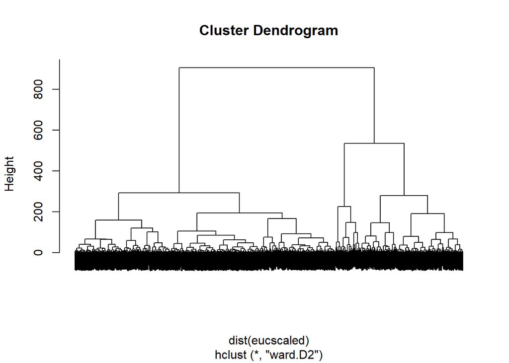

```r
wdbcc_sc <- scale(wdbcc, T, T)
eucscaled <- dist(wdbcc_sc, method="euclidean")
wardscaled <-  hclust(dist(eucscaled),method="ward.D2")
plot(wardscaled, labels = F)
```

```r
#k=3 seems reasonable
wardscaled3 <- cutree(wardscaled, k=3)
```

### Ward method (unscaled data)

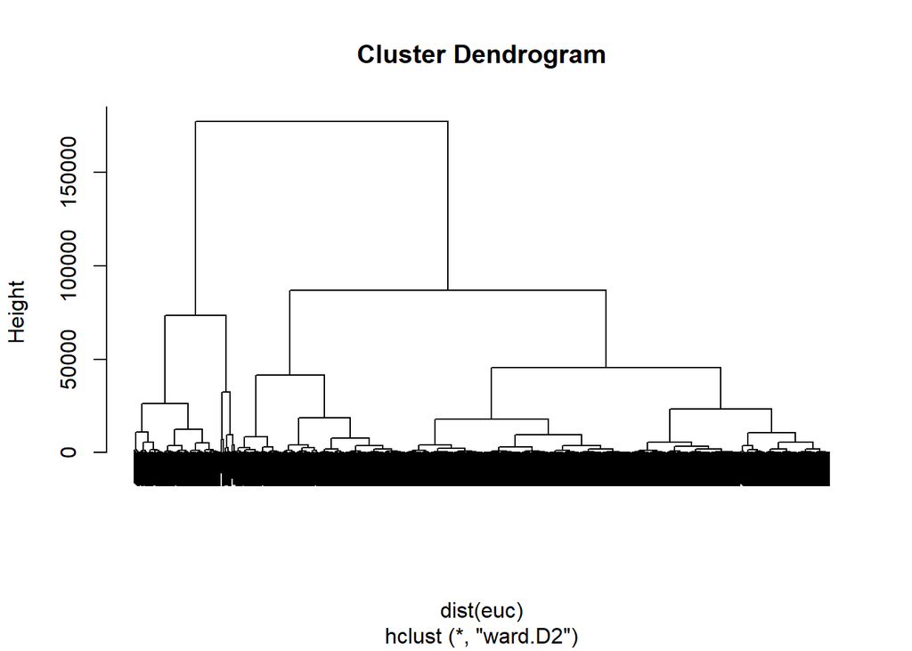

```r
euc <- dist(wdbcc, method = "euclidean")
ward <-  hclust(dist(euc),method="ward.D2")
plot(ward, labels = F)    ##choose k=4
```

```r
ward4 <- cutree(ward, k=4)
```

### Visualize clusterings in 2 dimensions

```r
pc <- princomp(wdbcc, cor = TRUE)
summary(pc)
```

```
## Importance of components:
##                           Comp.1    Comp.2     Comp.3     Comp.4     Comp.5
## Standard deviation     2.3406384 1.5870456 0.93841099 0.70640600 0.61035989
## Proportion of Variance 0.5478588 0.2518714 0.08806152 0.04990094 0.03725392
## Cumulative Proportion  0.5478588 0.7997302 0.88779168 0.93769262 0.97494654
##                            Comp.6      Comp.7      Comp.8      Comp.9
## Standard deviation     0.35233755 0.282993481 0.186788096 0.105524692
## Proportion of Variance 0.01241417 0.008008531 0.003488979 0.001113546
## Cumulative Proportion  0.98736071 0.995369244 0.998858223 0.999971769
##                             Comp.10
## Standard deviation     1.680196e-02
## Proportion of Variance 2.823059e-05
## Cumulative Proportion  1.000000e+00
```

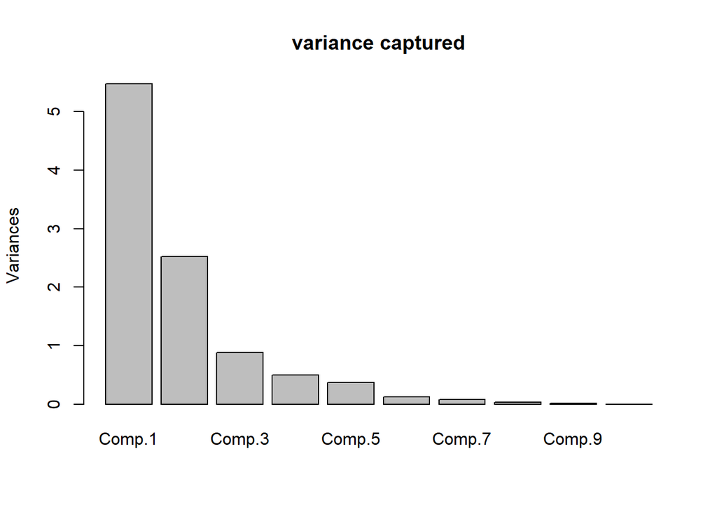

```r
plot(pc, main = "variance captured")
```

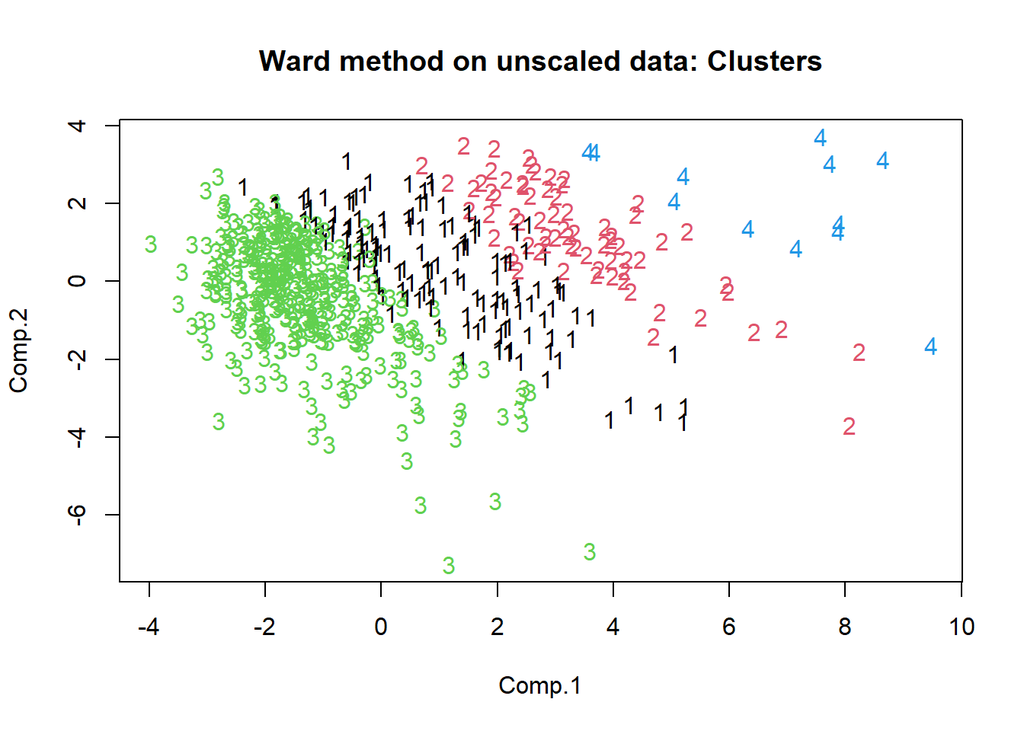

```r
library(fpc)
plot(pc$scores,col=ward4,pch=clusym[ward4], main = "Ward method on unscaled data: Clusters")
```

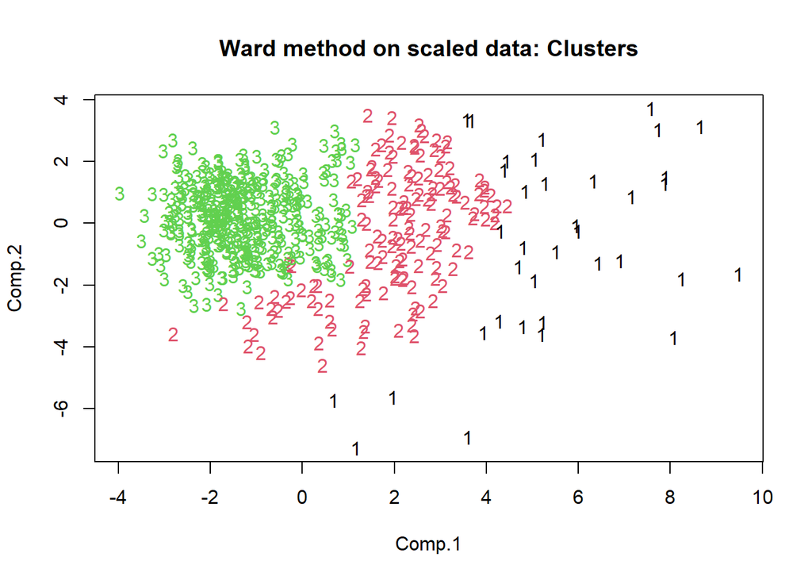

```r
plot(pc$scores,col=wardscaled3 ,pch=clusym[wardscaled3], main = "Ward method on scaled data: Clusters")
```

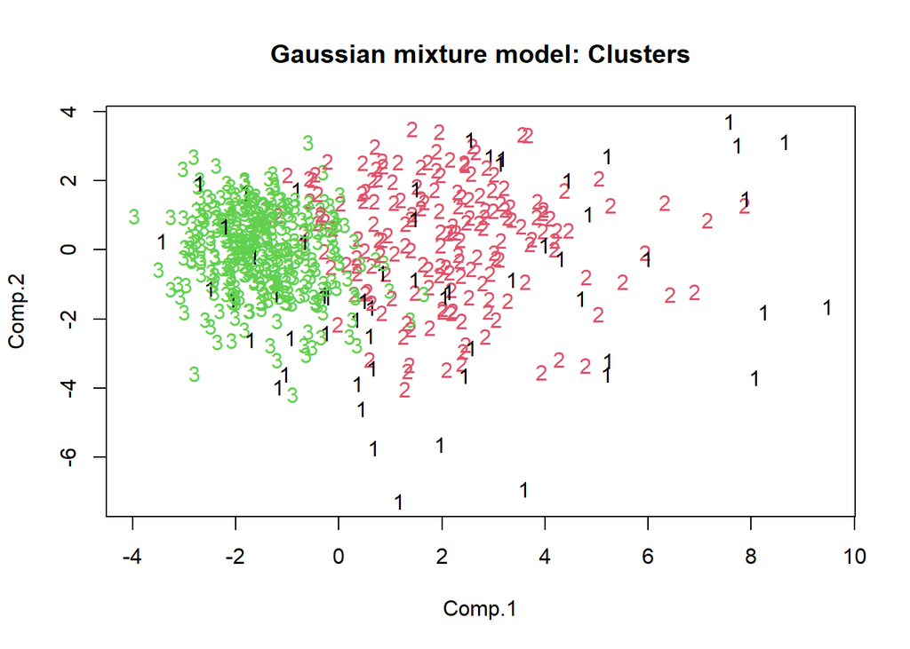

```r
plot(pc$scores,col=mixtwdbc$classification,pch=clusym[mixtwdbc$classification], main = "Gaussian mixture model: Clusters")
```

Among these three, I would choose the Ward method on scaled data. Since we are looking at medical data, I would like to have a small number of cluster and to have a sort of separation between them. Plus, with unscaled data some variables with higher size would have more importance in the computation of the distances: this could be bad, at least in this field (we are not medical experts). The Gaussian mixture is able to find another clustering pattern in the data, but, as I said before, any kind of overlapping in my opinion seems undesirable.